# Investigating genomic and phenotypic parallelism between piscivorous and planktivorous lake trout (Salvelinus namaycush) ecotypes by means of RADseq and morphometrics analyses

Author

Fernando Chuquizuta Chavez, Maria Noelia Noriega Cortez, Jessenia Shirley Ramos Armaulia

# 1 Título

**Investigating genomic and phenotypic parallelism between piscivorous and planktivorous lake trout (*Salvelinus namaycush*) ecotypes by means of RADseq and morphometrics analyses**

# 2 **Descripción**

El archivo investiga el paralelismo genómico y fenotípico entre ecotipos de trucha de lago (*Salvelinus namaycush*) piscívoros y planctívoros utilizando análisis de RADseq y morfometría. Se examinan diferencias en morfología y estructura genética, concluyendo que existen dos ecotipos con características morfológicas adaptativas diferentes relacionadas con sus tácticas de forrajeo, además de identificar loci potencialmente bajo selección genética

# 3 Referencias

- Bernatchez, S., Laporte, M., Perrier, C., Sirois, P., & Bernatchez, L. (2016). Investigating genomic and phenotypic parallelism between piscivorous and planktivorous lake trout (Salvelinus namaycush) ecotypes by means of RADseq and morphometrics analyses. *Molecular ecology*, *25*(19), 4773–4792. https://doi.org/10.1111/mec.13795

# 4 DOI

- https://doi.org/10.1111/mec.13795

# 5 Librerias y configuración

```
Project:  C:/Users/USUARIO/Documents/git/DG-2025-I
```

# 6 Importación de datos

> url: https://docs.google.com/spreadsheets/d/1DIFQg1WL8kilk5PIQ19nELga6gK1beRI5AcEkXesfuE/edit?gid=332267912#gid=332267912

*Nota*: Esta url data dirección a la base de datos del paper en una nube de drive

```
## tibble [105 × 22] (S3: tbl_df/tbl/data.frame)
##  $ ID                  : chr [1:105] "DE-01" "DE-02" "DE-03" "DE-05" ...
##  $ fork_length         : chr [1:105] "495" "344" "517" "411" ...
##  $ weight_g            : chr [1:105] "1181.9" "412.7" "1417.1" "639.2" ...
##  $ fulton              : chr [1:105] "238767.7" "119970.9" "274100.6" "155523.1" ...
##  $ gillraker_nb        : chr [1:105] "19" "19" "20" "17" ...
##  $ gill_raker_lenght_mm: chr [1:105] "8.11" "6.64" "7.89" "7.09" ...
##  $ gill_raker_width_mm : chr [1:105] "1.31" "0.8" "1.05" "0.8" ...
##  $ linear_measurment_1 : chr [1:105] "450.586" "312.657" "469.739" "37.201" ...
##  $ linear_measurment_2 : chr [1:105] "546.929" "404.142" "630.467" "489.472" ...
##  $ linear_measurment_3 : chr [1:105] "522.311" "397.337" "581.261" "482.553" ...
##  $ linear_measurment_4 : chr [1:105] "509.964" "387.654" "573.732" "455.207" ...
##  $ linear_measurment_5 : chr [1:105] "400.436" "292.926" "422.517" "34.997" ...
##  $ linear_measurment_6 : chr [1:105] "850.363" "611.149" "913.964" "769.895" ...
##  $ linear_measurment_7 : chr [1:105] "176.381" "152.442" "170.072" "149.113" ...
##  $ linear_measurment_8 : chr [1:105] "679.922" "48.084" "74.046" "586.473" ...
##  $ linear_measurment_9 : chr [1:105] "625.136" "474.782" "646.737" "579.281" ...
##  $ linear_measurment_10: chr [1:105] "880.127" "652.066" "938.577" "874.272" ...
##  $ linear_measurment_11: chr [1:105] "454.596" "321.991" "482.053" "380.427" ...
##  $ linear_measurment_12: chr [1:105] "53.348" "391.682" "588.875" "571.944" ...
##  $ linear_measurment_13: chr [1:105] "518.271" "349.427" "627.878" "518.637" ...
##  $ linear_measurment_14: chr [1:105] "683.594" "467.453" "791.521" "674.284" ...
##  $ linear_measurment_15: chr [1:105] "938.905" "665.747" "983.933" "737.363" ...
## tibble [105 × 4] (S3: tbl_df/tbl/data.frame)
##  $ ID     : chr [1:105] "DE-01" "DE-02" "DE-03" "DE-05" ...
##  $ lake   : chr [1:105] "desert" "desert" "desert" "desert" ...
##  $ sex    : chr [1:105] "F" "F" "M" "F" ...
##  $ ecotype: chr [1:105] "pisc" "pisc" "pisc" "pisc" ...
```

# 7 Unir base de datos

```
## 'data.frame':    105 obs. of  25 variables:
##  $ ID                  : chr  "BO-01" "BO-02" "BO-03" "BO-04" ...
##  $ lake                : chr  "bondy" "bondy" "bondy" "bondy" ...
##  $ sex                 : chr  "M" "M" "M" "F" ...
##  $ ecotype             : chr  "planc" "planc" "planc" "planc" ...
##  $ fork_length         : num  363 400 358 408 391 373 345 364 418 400 ...
##  $ weight_g            : num  505 550 422 677 451 ...
##  $ fulton              : num  139174 137600 117849 165882 115243 ...
##  $ gillraker_nb        : num  20 19 20 21 22 21 21 22 24 23 ...
##  $ gill_raker_lenght_mm: num  6.61 7.38 7.22 7.4 7.39 7.27 6.9 7.46 7.26 8.29 ...
##  $ gill_raker_width_mm : num  0.89 0.91 0.73 0.93 0.83 0.73 0.89 0.81 0.8 1 ...
##  $ linear_measurment_1 : num  330 371 333 381 362 ...
##  $ linear_measurment_2 : num  404.9 51.6 431.3 467.5 467.9 ...
##  $ linear_measurment_3 : num  370 492 404 436 447 ...
##  $ linear_measurment_4 : num  362.8 452.1 398.8 417 40.6 ...
##  $ linear_measurment_5 : num  308 375 323 359 361 ...
##  $ linear_measurment_6 : num  649 792 638 723 705 ...
##  $ linear_measurment_7 : num  13.6 163.6 159.9 165.5 170.9 ...
##  $ linear_measurment_8 : num  480.28 5.76 497.91 539.97 501.74 ...
##  $ linear_measurment_9 : num  459.7 469.1 466.5 505.5 46.4 ...
##  $ linear_measurment_10: num  662 621 673 724 680 ...
##  $ linear_measurment_11: num  309 344 306 369 322 ...
##  $ linear_measurment_12: num  395 432 415 446 428 ...
##  $ linear_measurment_13: num  364.2 365.4 423.8 41.7 424.7 ...
##  $ linear_measurment_14: num  51.4 639.3 588 575.9 546.4 ...
##  $ linear_measurment_15: num  655.2 687.2 64.3 767.2 639.9 ...
```

| ID | lake | sex | ecotype | fork_length | weight_g | fulton | gillraker_nb | gill_raker_lenght_mm | gill_raker_width_mm | linear_measurment_1 | linear_measurment_2 | linear_measurment_3 | linear_measurment_4 | linear_measurment_5 | linear_measurment_6 | linear_measurment_7 | linear_measurment_8 | linear_measurment_9 | linear_measurment_10 | linear_measurment_11 | linear_measurment_12 | linear_measurment_13 | linear_measurment_14 | linear_measurment_15 |
| --- | --- | --- | --- | --- | --- | --- | --- | --- | --- | --- | --- | --- | --- | --- | --- | --- | --- | --- | --- | --- | --- | --- | --- | --- |
| BO-01 | bondy | M | planc | 363 | 505.2 | 139173.6 | 20 | 6.61 | 0.89 | 329.787 | 404.944 | 369.543 | 362.766 | 307.737 | 649.427 | 13.569 | 480.276 | 459.736 | 662.095 | 308.921 | 394.699 | 364.222 | 51.395 | 655.244 |
| BO-02 | bondy | M | planc | 400 | 550.4 | 137600.0 | 19 | 7.38 | 0.91 | 371.224 | 51.565 | 491.644 | 452.135 | 374.796 | 791.797 | 163.611 | 5.763 | 469.145 | 621.328 | 343.891 | 431.746 | 365.402 | 639.265 | 687.169 |
| BO-03 | bondy | M | planc | 358 | 421.9 | 117849.2 | 20 | 7.22 | 0.73 | 332.607 | 431.284 | 404.326 | 398.764 | 322.532 | 637.767 | 159.937 | 497.911 | 466.474 | 673.419 | 306.061 | 414.997 | 423.794 | 588.046 | 64.331 |
| BO-04 | bondy | F | planc | 408 | 676.8 | 165882.4 | 21 | 7.40 | 0.93 | 380.528 | 467.497 | 435.754 | 417.029 | 359.342 | 723.451 | 165.469 | 539.965 | 505.458 | 723.526 | 369.052 | 446.097 | 41.662 | 575.904 | 767.208 |
| BO-05 | bondy | F | planc | 391 | 450.6 | 115243.0 | 22 | 7.39 | 0.83 | 361.767 | 467.946 | 446.645 | 40.586 | 361.264 | 704.532 | 170.883 | 501.744 | 46.391 | 680.325 | 321.789 | 428.489 | 424.697 | 546.402 | 639.903 |
| BO-06 | bondy | F | planc | 373 | 501.5 | 134450.4 | 21 | 7.27 | 0.73 | 340.359 | 429.935 | 417.772 | 409.857 | 324.099 | 681.375 | 139.909 | 51.424 | 474.724 | 711.014 | 305.197 | 398.822 | 383.908 | 533.546 | 679.713 |
| BO-07 | bondy | M | planc | 345 | 401.2 | 116289.9 | 21 | 6.90 | 0.89 | 317.602 | 412.283 | 385.176 | 368.173 | 30.317 | 637.814 | 132.719 | 479.939 | 451.853 | 68.843 | 294.859 | 414.904 | 398.697 | 504.437 | 621.722 |
| BO-08 | bondy | M | planc | 364 | 480.8 | 132087.9 | 22 | 7.46 | 0.81 | 340.137 | 461.765 | 425.614 | 422.382 | 342.596 | 712.418 | 14.526 | 535.766 | 518.551 | 668.178 | 343.763 | 434.674 | 408.744 | 561.065 | 684.823 |
| BO-09 | bondy | M | planc | 418 | 766.8 | 183445.0 | 24 | 7.26 | 0.80 | 384.371 | 547.822 | 502.586 | 463.726 | 4.001 | 816.211 | 164.784 | 612.847 | 495.237 | 739.426 | 372.814 | 446.319 | 462.986 | 623.615 | 809.106 |
| BO-10 | bondy | M | planc | 400 | 545.6 | 136400.0 | 23 | 8.29 | 1.00 | 375.415 | 496.433 | 457.654 | 422.374 | 370.374 | 761.399 | 167.909 | 531.993 | 507.914 | 673.015 | 386.774 | 468.954 | 422.058 | 601.796 | 686.689 |
| BO-11 | bondy | F | planc | 363 | 439.6 | 121101.9 | 21 | 6.50 | 0.69 | 339.382 | 393.158 | 362.846 | 356.189 | 29.699 | 618.133 | 14.526 | 454.662 | 483.482 | 661.635 | 307.523 | 441.042 | 369.797 | 523.023 | 648.956 |
| BO-12 | bondy | F | planc | 505 | 1444.5 | 286039.6 | 20 | 7.43 | 1.34 | 465.479 | 559.665 | 524.861 | 569.101 | 433.456 | 920.696 | 165.437 | 761.499 | 598.444 | 836.992 | 437.901 | 52.693 | 511.381 | 718.405 | 105.939 |
| BO-13 | bondy | M | planc | 373 | 559.2 | 149919.6 | 19 | 7.73 | 0.99 | 34.448 | 444.121 | 417.011 | 407.077 | 343.102 | 698.143 | 140.763 | 529.646 | 511.229 | 711.063 | 333.399 | 442.171 | 445.323 | 584.971 | 74.088 |
| BO-14 | bondy | M | planc | 352 | 455.2 | 129318.2 | 20 | 5.57 | 0.92 | 328.691 | 417.804 | 375.129 | 3.782 | 323.764 | 610.021 | 137.061 | 483.415 | 498.521 | 611.346 | 318.652 | 382.513 | 398.141 | 546.152 | 666.748 |
| BO-15 | bondy | F | planc | 343 | 435.9 | 127084.5 | 21 | 7.31 | 0.73 | 326.628 | 393.058 | 369.601 | 360.841 | 30.474 | 638.639 | 133.884 | 478.921 | 463.035 | 630.087 | 323.351 | 368.735 | 322.619 | 503.489 | 663.763 |
| BO-20 | bondy | M | planc | 338 | 427.0 | 126331.4 | 21 | 6.69 | 0.68 | 312.103 | 350.172 | 329.779 | 351.663 | 275.861 | 619.192 | 125.583 | 483.663 | 439.774 | 607.338 | 288.903 | 387.038 | 352.947 | 519.932 | 630.876 |
| BO-22 | bondy | M | planc | 341 | 390.2 | 114428.2 | 23 | 6.79 | 0.69 | 315.712 | 3.836 | 368.783 | 356.129 | 309.134 | 631.285 | 135.172 | 46.473 | 461.919 | 642.543 | 296.292 | 380.572 | 372.612 | 495.877 | 616.552 |
| BO-23 | bondy | M | planc | 377 | 467.1 | 123899.2 | 22 | 7.77 | 0.88 | 354.934 | 445.766 | 413.614 | 387.619 | 355.228 | 730.834 | 14.812 | 514.717 | 490.955 | 68.243 | 35.597 | 413.718 | 41.669 | 551.253 | 657.324 |
| BO-24 | bondy | M | planc | 394 | 599.4 | 152132.0 | 19 | 6.79 | 0.92 | 364.343 | 491.714 | 45.788 | 428.057 | 354.509 | 755.846 | 154.564 | 552.788 | 526.102 | 730.527 | 370.923 | 411.255 | 439.203 | 592.368 | 745.607 |
| BO-28 | bondy | F | planc | 386 | 514.8 | 133367.9 | 21 | 6.51 | 0.90 | 360.025 | 402.779 | 385.849 | 372.523 | 325.729 | 676.503 | 134.574 | 500.041 | 479.602 | 703.678 | 319.971 | 419.758 | 408.995 | 512.854 | 630.822 |
| BO-29 | bondy | F | planc | 307 | 268.5 | 87459.3 | 22 | 6.21 | 0.64 | 282.686 | 32.377 | 311.286 | 295.581 | 254.571 | 520.878 | 114.528 | 392.666 | 383.374 | 61.004 | 265.917 | 324.387 | 296.769 | 428.423 | 507.197 |
| BO-30 | bondy | M | planc | 443 | 961.7 | 217088.0 | 22 | 7.31 | 0.96 | 411.923 | 521.811 | 484.276 | 480.695 | 41.062 | 808.215 | 146.315 | 631.495 | 539.324 | 820.047 | 401.929 | 51.758 | 510.588 | 729.951 | 857.486 |
| CA-01 | caugnawana | F | planc | 372 | 544.7 | 146424.7 | 17 | 6.77 | 0.84 | 366.479 | 382.041 | 346.103 | 402.145 | 317.566 | 674.913 | 142.231 | 549.829 | 48.336 | 649.787 | 36.249 | 40.029 | 418.167 | 570.161 | 785.691 |
| CA-03 | caugnawana | M | planc | 375 | 580.5 | 154800.0 | 20 | 5.80 | 0.69 | 37.510 | 386.584 | 357.072 | 423.368 | 310.583 | 680.979 | 145.988 | 577.343 | 486.527 | 666.382 | 390.777 | 407.073 | 417.236 | 51.512 | 847.945 |
| CA-07 | caugnawana | F | planc | 408 | 716.0 | 175490.2 | 19 | 7.20 | 0.70 | 386.169 | 513.929 | 46.604 | 444.933 | 396.191 | 741.255 | 168.908 | 551.898 | 517.357 | 712.105 | 360.598 | 465.493 | 433.822 | 572.778 | 825.493 |
| CA-12 | caugnawana | M | planc | 362 | 492.6 | 136077.3 | 19 | 6.20 | 0.74 | 33.798 | 375.646 | 343.689 | 35.731 | 288.413 | 612.436 | 137.346 | 492.572 | 424.939 | 576.046 | 353.565 | 393.393 | 35.352 | 531.192 | 714.955 |
| CA-14 | caugnawana | M | planc | 398 | 646.6 | 162462.3 | 20 | 7.36 | 0.68 | 366.725 | 430.598 | 39.328 | 425.769 | 33.166 | 739.558 | 140.611 | 583.478 | 503.658 | 638.408 | 393.613 | 41.138 | 418.516 | 631.165 | 793.593 |
| CA-19 | caugnawana | M | planc | 348 | 517.1 | 148592.0 | 18 | 6.25 | 0.83 | 326.947 | 413.421 | 389.667 | 371.013 | 319.756 | 644.385 | 157.343 | 5.149 | 456.016 | 575.025 | 325.537 | 370.504 | 360.114 | 53.098 | 769.913 |
| CA-25 | caugnawana | M | planc | 378 | 567.0 | 150000.0 | 19 | 5.97 | 0.69 | 348.604 | 455.565 | 433.587 | 420.825 | 334.292 | 738.789 | 143.867 | 554.511 | 454.362 | 620.492 | 341.444 | 419.108 | 398.755 | 54.969 | 787.796 |
| CA-26 | caugnawana | M | planc | 378 | 575.4 | 152222.2 | 20 | 6.92 | 0.85 | 35.271 | 38.841 | 349.325 | 393.081 | 279.985 | 63.614 | 130.283 | 537.244 | 446.345 | 586.586 | 362.521 | 379.851 | 363.921 | 556.775 | 759.896 |

[output cut: 75 more lines]

# 8 Análisis de componentes principales - PCA

### 8.0.1 PCA por agrupación por lagos

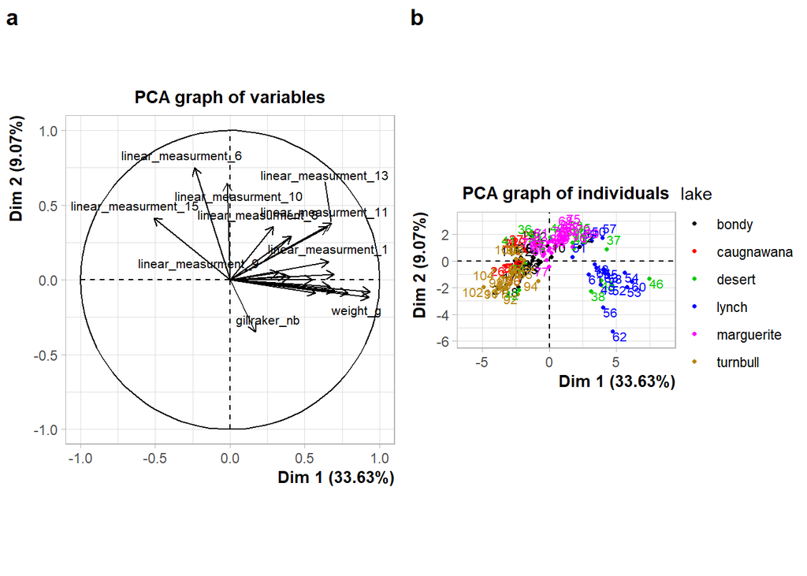

### 8.0.2 PCA por agrupación por sexo

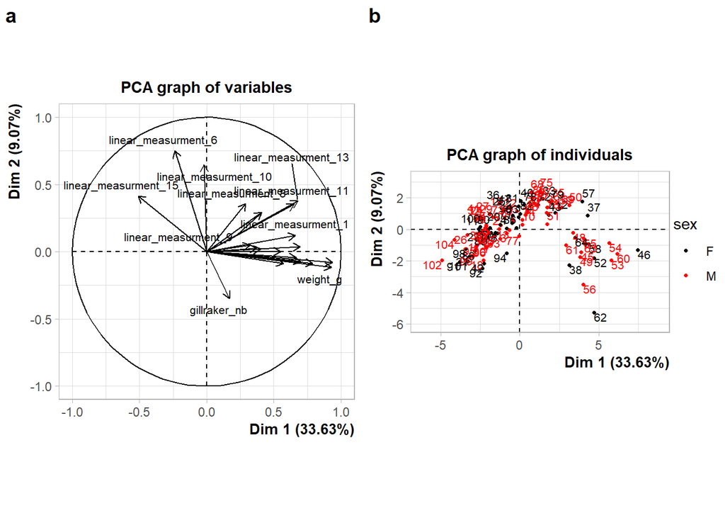

### 8.0.3 PCA por agrupación por ecotipo

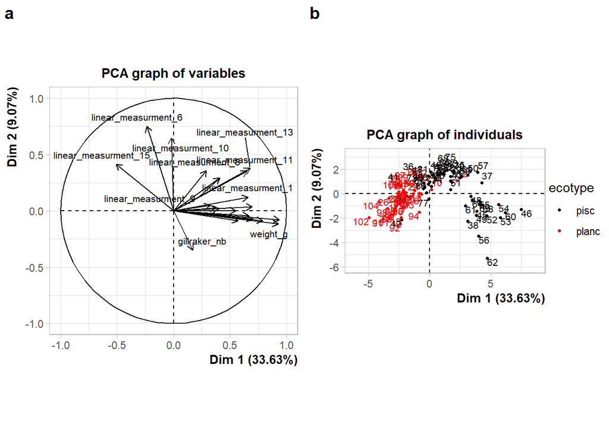

```
##
## Call:
## PCA(X = fb, scale.unit = T, quali.sup = 1:5, graph = F)
##
##
## Eigenvalues
##                       Dim.1  Dim.2  Dim.3  Dim.4  Dim.5  Dim.6  Dim.7  Dim.8
## Variance               6.73   1.81   1.36   1.16   1.07   0.99   0.94   0.87
## % of var.             33.63   9.07   6.81   5.82   5.33   4.95   4.68   4.36
## Cumulative % of var.  33.63  42.71  49.52  55.34  60.67  65.61  70.29  74.65
##                       Dim.9 Dim.10 Dim.11 Dim.12 Dim.13 Dim.14 Dim.15 Dim.16
## Variance               0.74   0.73   0.67   0.56   0.52   0.46   0.39   0.33
## % of var.              3.71   3.63   3.36   2.82   2.61   2.28   1.93   1.65
## Cumulative % of var.  78.36  81.99  85.36  88.18  90.79  93.07  95.00  96.65
##                      Dim.17 Dim.18 Dim.19 Dim.20
## Variance               0.24   0.24   0.19   0.00
## % of var.              1.22   1.19   0.94   0.01
## Cumulative % of var.  97.86  99.06  99.99 100.00
##
## Individuals
##                         Dist   Dim.1   ctr  cos2   Dim.2   ctr  cos2   Dim.3
## 1                    |  3.97 | -2.19  0.68  0.30 |  0.10  0.00  0.00 | -0.57
## 2                    |  3.36 | -1.30  0.24  0.15 |  0.01  0.00  0.00 | -1.00
## 3                    |  2.23 | -0.83  0.10  0.14 | -0.26  0.04  0.01 |  0.29
## 4                    |  2.70 | -0.84  0.10  0.10 |  0.04  0.00  0.00 |  0.31
## 5                    |  3.61 | -1.56  0.35  0.19 | -0.21  0.02  0.00 |  0.17
## 6                    |  2.57 | -1.41  0.28  0.30 | -0.24  0.03  0.01 | -0.57
## 7                    |  3.28 | -1.85  0.48  0.32 | -0.94  0.46  0.08 |  0.83
## 8                    |  3.46 | -1.20  0.20  0.12 |  0.27  0.04  0.01 |  0.96
## 9                    |  3.66 | -0.45  0.03  0.02 |  0.65  0.22  0.03 |  1.66
## 10                   |  2.40 |  0.16  0.00  0.00 |  0.31  0.05  0.02 |  0.76
## 11                   |  4.22 | -2.59  0.95  0.38 |  0.02  0.00  0.00 |  0.95
## 12                   |  3.81 |  2.24  0.71  0.35 |  1.06  0.59  0.08 |  1.57
## 13                   |  2.86 | -0.65  0.06  0.05 | -0.06  0.00  0.00 |  0.31
## 14                   |  3.23 | -2.13  0.64  0.44 |  0.27  0.04  0.01 |  0.12
## 15                   |  2.89 | -2.02  0.58  0.49 | -0.06  0.00  0.00 |  0.84
## 16                   |  2.25 | -2.03  0.58  0.81 | -0.16  0.01  0.00 |  0.36
## 17                   |  3.92 | -2.46  0.86  0.39 | -0.82  0.35  0.04 | -0.04
## 18                   |  5.24 | -2.32  0.76  0.20 | -1.97  2.04  0.14 |  1.40
## 19                   |  2.72 | -1.06  0.16  0.15 |  1.23  0.80  0.21 | -0.18
```

[output cut: 699 more lines]

```
## linear_measurment_1   8.57641370
## linear_measurment_2   0.52592192
## linear_measurment_3   5.43001806
## linear_measurment_4   3.41536157
## linear_measurment_5   8.12023553
## linear_measurment_6   3.57193177
## linear_measurment_7   6.15682224
## linear_measurment_8   1.00896663
## linear_measurment_9   4.20814298
## linear_measurment_10  2.02105539
## linear_measurment_11  8.66050770
## linear_measurment_12 27.76095049
## linear_measurment_13  2.61838583
## linear_measurment_14  1.26886221
## linear_measurment_15  1.83786977
```

**#Interpretación**

Los dos primeros componentes Comp1 y Comp2 detallan el 33.63% y 9.07% de la varianza

# 9 Análisis de Cluster

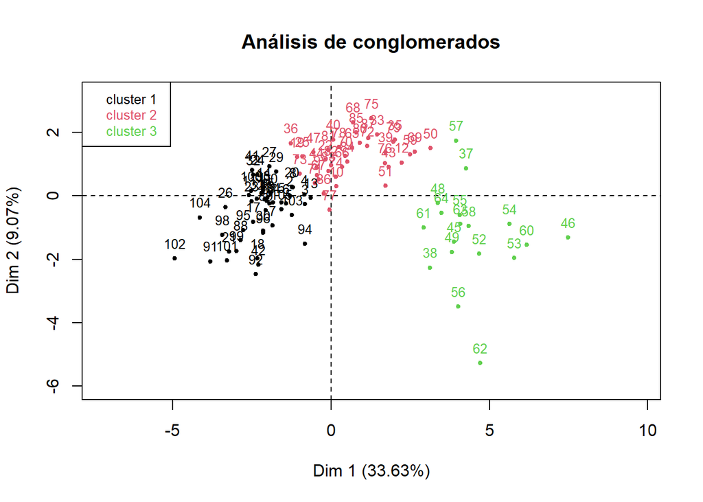

**#Interpretación**

EL análisis de clustering mostró la formación de tres grupos en base a Hierarchical Clustering on Principle Components con el analsis morfológico del presetne estudio